# ProgettoScandino

Leonardo Scandino

15/2/2021

###——-Caricamento librerie e csv

###——-Introduzione Informazioni sui Dataset:

Suicide Rates Overview 1985 to 2016 -> Dataset di kaggle che raccoglie i suicidi nel range di anni tra ’85 e il ’16. Al suo interno raccoglie diverse variabili, quelle utilizzate nel seguente progetto sono: country, year, sex, age, suicides_no, population, generation.

World Happiness report 2015 -> Dataset di kaggle che raccoglie il livello di felicità di molteplici paesi, al suo interno presenta il livello di Happiness score e le variabili che lo formano : GDP per Capita, Family, Health, Freedom, Government Corruption, Generosity, Dystopia Residual. Questi parametri sono assocciati a country e region.

Il fine di questo progetto è analizzare i dati relativi hai suicidi dall’anno 1985 al 2016 dei vari paesi e trovare informazioni interessanti sull’argomento. Successivamente intersecare a questi dati il dataset World Happiness e vedere se ci sono relazioni tra i due argomenti.

###——-Analisi globale sui suicidi

##–1 Per iniziare filtriamo i 10 paesi con tasso di suicidio più alto (dal 1985-2016). Notiamo subito che la Lithuania ha un tasso di suicidio molto elevato e si posiziona al primo posto

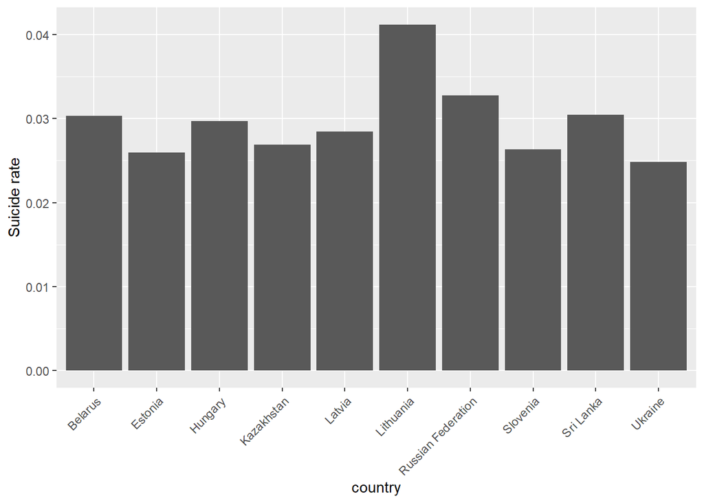

```r
suicideGlobale <- suicide.test %>%
  group_by(country) %>%
  summarise(n_suicides = sum(suicides_no), tot_pop = sum(as.numeric(population)), Tasso_suicide_global = (n_suicides/tot_pop)*100) %>%
  arrange(-Tasso_suicide_global)%>%
  select(country, n_suicides, Tasso_suicide_global)%>%
  head(10)%>%
  ggplot()+
  geom_col(aes(country, Tasso_suicide_global))+
  theme(axis.text.x = element_text(angle = 45, vjust = 1, hjust = 1))+
  labs(y="Suicide rate")

suicideGlobale
```

##–2 In seguito scopriamo il tasso di suicidio globale tra maschi e femmine (dal 1985-2016). I maschi hanno un tasso molto più alto delle femmine ( 0.77 contro 0.23)

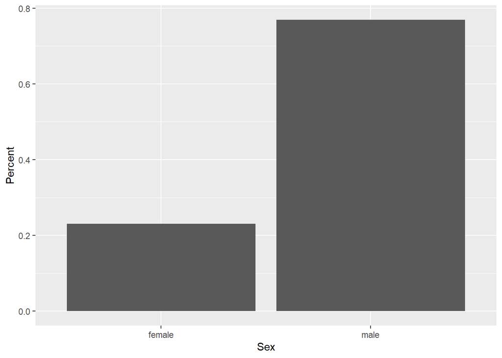

```r
tot_suicides <- suicide.test %>% summarise(sum(suicides_no))

MeF_globale <-suicide.test %>%
  group_by(sex) %>%
  count(sumsuicide = sum(suicides_no))%>%
  select(sex, sumsuicide) %>%
  mutate(percent= sumsuicide/as.numeric(tot_suicides))%>%
  ggplot(aes(sex,percent) )+
  geom_col()+
  labs(x = "Sex", y = "Percent")

MeF_globale
```

Approfondiamo questo aspetto e osserviamo l’andamento dei suicidi tra maschi e femmine anno per anno. Confermando che il tasso di suicidio dei maschi è sempre più alto di quello delle femmine e evidenziando un picco nell’anno 1995

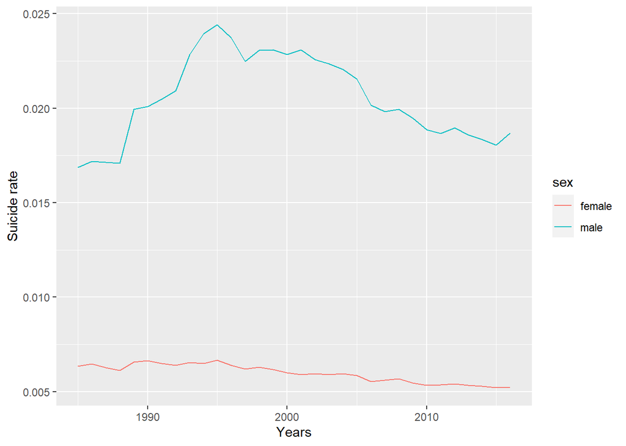

```r
MeF_per_anno <-suicide.test %>%
  group_by(year, sex) %>% #per avere le generazioni aggiungi age nei gruppi
  summarise(suicides = sum(suicides_no), totPopulation = sum(population))%>%
  mutate(Tasso_per_anno = suicides/totPopulation*100) %>%
  ggplot(aes(year,Tasso_per_anno, color = sex))+
  geom_line()+
  labs(x = "Years", y = "Suicide rate")

MeF_per_anno
```

Eseguiamo la stessa tipologia di analisi mettendo in evidenza le classi d’età. Notiamo che la generazione over 75 è quella con tasso di suicidio più alto (con un massimo nel 1990) mentre si evidenzia un picco generale nel 1995, complessivamente però il tasso è in discesa.

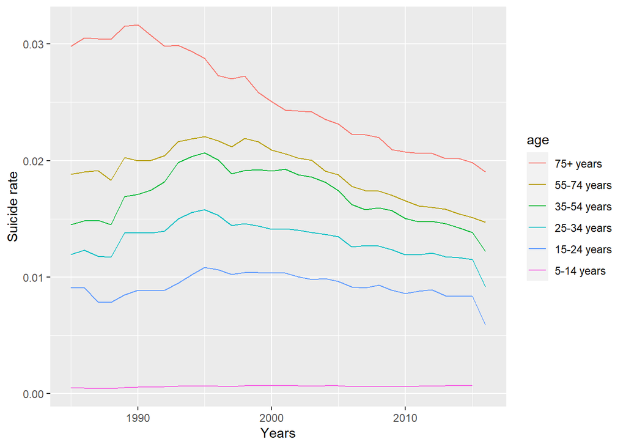

```r
age_order <- unique(suicide.test$age)[c(3,5,2,4,1,6)] #ordino i nomi delle classi per mettere in ordine i nomi nella legenda del grafico


Generation_per_anno <- suicide.test %>%
  mutate(age = fct_relevel(age, age_order)) %>%
  group_by(year, age) %>%
  summarise(suicides = sum(suicides_no), totPopulation = sum(population))%>%
  mutate(Tasso_per_anno = suicides/totPopulation*100) %>%
  ggplot(aes(year,Tasso_per_anno, color = age))+
  geom_line()+
  labs(x = "Years", y = "Suicide rate")

Generation_per_anno
```

##3–

Creiamo una Shiny app che evidenzia la percentuale di suicidi globali per tutti gli anni disponibili (cercando di confermare la Lithuania come primo posto)

```r
#costruzione dataset con dati ragruppati per anno e country con aggiunta di Tasso globale in percentuale
prova <- suicide.test %>%
   group_by(country, year) %>%
  summarise(tot_global_suicides= sum(suicides_no), tot_population = sum(population), Tasso_suicide_global = tot_global_suicides/tot_population*100)
```

ShinyApp

```r
# Define UI for app that draws a histogram ----
ui <- fluidPage(

  # App title ----
  titlePanel("Tasso di suicidi di ogni paese per ogni anno"),

  # Sidebar layout with input and output definitions ----
  sidebarLayout(

    # Sidebar panel for inputs ----
    sidebarPanel(

      # Input: Slider for the number of bins ----

      numericInput("num",
                        h3("Seleziona l'anno"),
                        value = 2000, min = 1985, max = 2016))

    ,

    # Main panel for displaying outputs ----
    mainPanel(

      plotOutput("MyPlot")

    )
  )
)
server <- function(input, output) {

  output$MyPlot <- renderPlot({

    max_y <- max(prova$Tasso_suicide_global) + 0.01

ggplot(prova %>% filter(year== input$num))+

  geom_point(aes(country, Tasso_suicide_global))+
  labs(x="Country" ,y = "Suicide rate")+
  guides(x= "none")+


  geom_point(data= prova %>%
              filter(year== input$num) %>%
              filter(Tasso_suicide_global>0.03), aes(country, Tasso_suicide_global), color= "red", vjust = -1) +


  geom_label_repel(data= prova %>%
              filter(year== input$num) %>%
              filter(Tasso_suicide_global>0.03),
              aes(country, Tasso_suicide_global,
                  label = country), box.padding = 0.5,
                  point.padding = 0.3,
                  segment.color = 'blue', color= "red")+

  ylim(0, max_y)

  })

}
SHINY_TUTTI_DATI <- shinyApp(ui = ui, server = server)

SHINY_TUTTI_DATI
```

Shiny applications not supported in static R Markdown documents

dato che nell’asse x i paesi non sono sempre gli stessi ho preso in considerazione un sottonsieme comune più ampio possibile (perdendo ovviamente alcuni paesi)

```r
#Estrae il sottoinsieme comune di country presente negli anni dal 1995-2015 in mondo da avere gli stessi elementi in asse x
country_common <- list()

for (y in c(1995:2015)){
  c_perYear <- prova %>%
    filter(year == y) %>%
    select(country)
  country_common[as.character(y)] <- c_perYear
}
c_common <- Reduce(intersect, country_common)


suicide.common <- prova%>%
  group_by(country)%>%
  filter(year>=1995 & year<2016)%>%
  filter(country %in% c(c_common))
```

Analisi che utilizza come asse x un sottoinsieme comune per ogni anno dal ’95 al ’15

```r
# Define UI for app that draws a histogram ----
ui <- fluidPage(

  # App title ----
  titlePanel("Tasso di suicidi di ogni paese per ogni anno"),

  # Sidebar layout with input and output definitions ----
  sidebarLayout(

    # Sidebar panel for inputs ----
    sidebarPanel(

      # Input: Slider for the number of bins ----

      numericInput("num",
                        h3("Seleziona l'anno"),
                        value = 2000, min = 1995, max = 2015))

    ,

    # Main panel for displaying outputs ----
    mainPanel(

      plotOutput("MyPlot")

    )
  )
)
server <- function(input, output) {

  output$MyPlot <- renderPlot({

    max_y <- max(suicide.common$Tasso_suicide_global) + 0.01

ggplot(suicide.common %>% filter(year== input$num))+

  geom_point(aes(country, Tasso_suicide_global))+
  labs(x="Country" ,y = "Suicide rate", title = "Sottoinsieme comune di Country per ogni anno")+
  guides(x= "none")+

  geom_point(data= suicide.common %>%
              filter(year== input$num) %>%
              filter(Tasso_suicide_global>0.03), aes(country, Tasso_suicide_global), color= "red", vjust = -1) +

   geom_label_repel(data= suicide.common %>%
              filter(year== input$num) %>%
              filter(Tasso_suicide_global>0.03),
              aes(country, Tasso_suicide_global,
                  label = country), box.padding = 0.5,
                  point.padding = 0.3,
                  segment.color = 'blue', color= "red")+

  ylim(0, max_y)

  })

}
SHINY_SOTTOINSIEME_COMUNE <- shinyApp(ui = ui, server = server)
SHINY_SOTTOINSIEME_COMUNE
```

Shiny applications not supported in static R Markdown documents

###——-Analisi specifica per anno 2015

Non avendo un dataset di World Happiness degli anni 90 (dataset non esistente) studiamo il 2015 per vedere se ci sono relazioni tra i suicidi e il livello di felicità(o dei singoli fattori utilizzati per calcolarlo)

Iniziamo con una breve analisi sui suicidi del 2015

##1–

Filtriamo i 10 Paesi con Tasso di suicidio più alto nel 2015

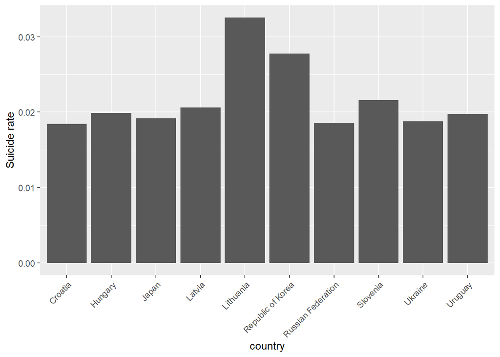

```r
suicide2015 <- suicide.test %>%
  group_by(country,year) %>%
  filter(year == '2015')%>%
  summarise(n_suicides = sum(suicides_no), tot_pop = sum(as.numeric(population)), Tasso_suicide_global = (n_suicides/tot_pop)*100) %>%
  arrange(-Tasso_suicide_global)%>%
  select(country,year, n_suicides, Tasso_suicide_global)%>%
  head(10)%>%
  ggplot()+
  geom_col(aes(country, Tasso_suicide_global))+
  theme(axis.text.x = element_text(angle = 45, vjust = 1, hjust = 1))+
  labs(y="Suicide rate")

suicide2015
```

##2–

Utilizzando il nostro dataset specifico del 2015, confrontiamo i tassi di suicidio tra maschi e femmine notiamo che i valori non si discostano da quello osservato nell’analisi globale, infatti rimangono 0.77 e 0.23

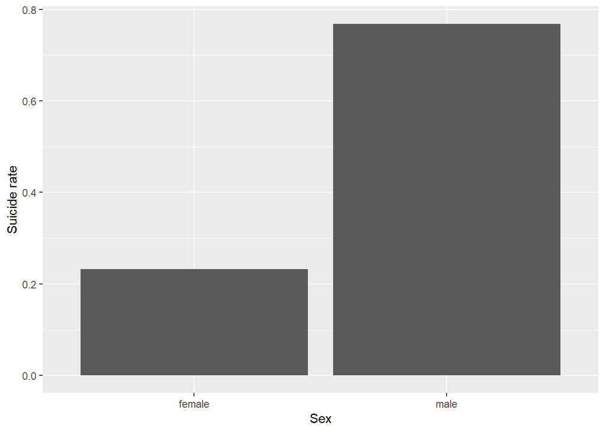

```r
tot_suicides_2015 <- suicide.test %>% filter(year == '2015') %>% summarise(sum(suicides_no))

sex2015 <- suicide.test %>%
  group_by(sex) %>%
  filter(year == '2015')%>%
  count(sumsuicide = sum(suicides_no)) %>%
  select(sex, sumsuicide) %>%
  mutate(percent = sumsuicide/as.numeric(tot_suicides_2015))%>%

  ggplot(aes(sex,percent) )+
  geom_col()+
  labs(x = "Sex", y = "Suicide rate")

sex2015
```

##3–

L’ultimo aspetto che osserviamo in questa fase è quello delle classi Anche qui si può notare che il tasso degli over 75 è molto alto rispetto a quello delle altre classi

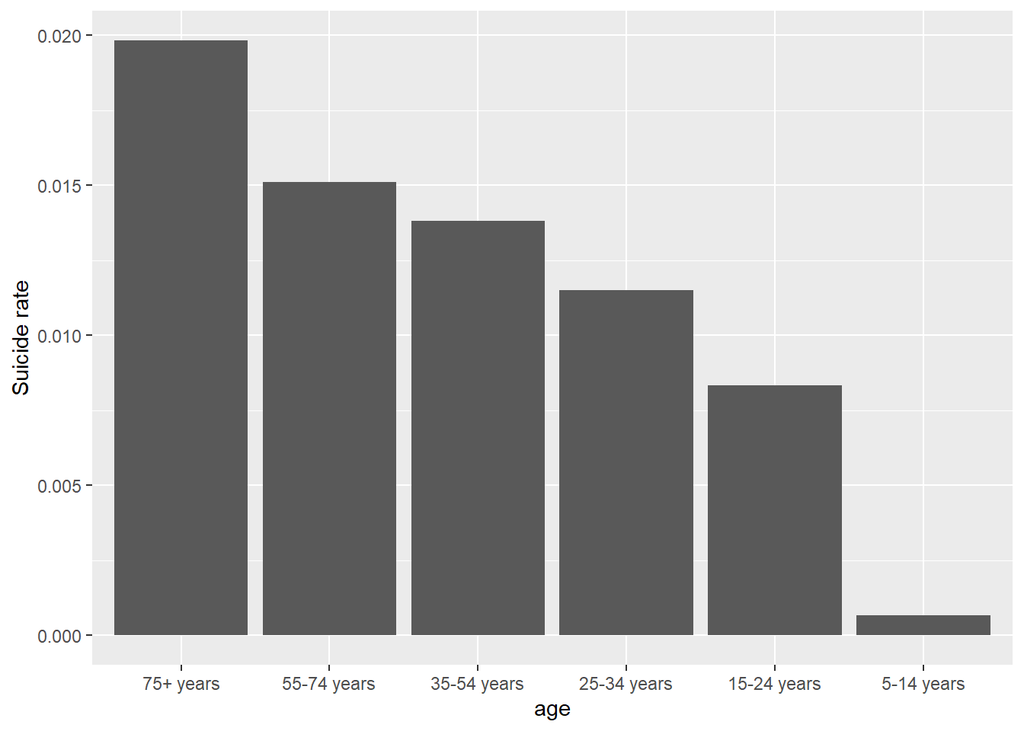

```r
age_order <- unique(suicide.test$age)[c(3,5,2,4,1,6)] #ordino i nomi delle classi per mettere in ordine i nomi nella legenda del grafico



age2015 <- suicide.test%>%
  filter(year=='2015')%>%
  mutate(age = fct_relevel(age, age_order))%>%
  group_by(age)%>%
  summarise(tot_population=sum(population),tot_suicide=sum(suicides_no),Tasso_suicide= tot_suicide/tot_population*100)%>%
  ggplot(aes(age,Tasso_suicide))+geom_col()+
  labs(y="Suicide rate")

age2015
```

###——-Analisi che cerca una relazione tra suicidi e livello di felicità(o delle sue variabili)

Intersechiamo i nostri due dataset e correggiamo lle variabili per le nostre analisi finali

```r
#rinomino colonna di suicide.test
suicide.test <- suicide.test%>%
  rename('gdp_per_capita' = 'gdp_per_capita ($)')
```

```r
#costruzione di una tabella suicide.2015 che raggruppa i country con la somma di tutti i suicidi e popolazioni
suicide.2015 <- suicide.test %>%
  filter(year == 2015) %>%
  group_by(country) %>%
  summarize(suicides = sum(suicides_no), Population = sum(population), Tasso_suicide_global = (suicides/Population)*100, gdp_per_capita= sum(gdp_per_capita))
```

```r
#rinomino le colonne per poter avere lo stesso nome per il join
happy.test.15 <- happy.test.15%>%
  rename( 'country' = 'Country',
          'Happiness_score'= 'Happiness Score',
          'Happiness_Rank' = 'Happiness Rank',
         'Economy_GDP_perCapita' ='Economy (GDP per Capita)',
         'Life_Expectancy' ='Health (Life Expectancy)',
         'Government_Corruption' ='Trust (Government Corruption)')
```

```r
#inner-join tra la tabella creata e quella degli happy
happy.suicide <- inner_join(suicide.2015,happy.test.15, by= 'country')
```

##1–

Mettendo a confronto il tasso di suicidio e il livello di felicità notiamo che non sembrerebbe esserci nessun tipo di collegamento tra i due, anzi si nota che molti paesi con molti suicidi sono felici e molti paesi con pochi suicidi non sono felici.

Per facilitare la visualizzazione i livelli di felicità più bassi sono stati colorati di rosso

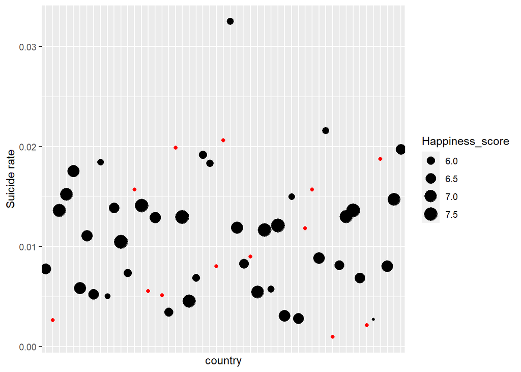

```r
happy.suicide%>%
  ggplot()+
  geom_point(data= happy.suicide%>%
               filter(Happiness_score >= 5.5),aes(country, Tasso_suicide_global, size = Happiness_score))+
   geom_point(data= happy.suicide%>%
               filter(Happiness_score < 5.5 ),aes(country, Tasso_suicide_global) ,color= "red")+
   guides(x="none")+ labs(y="Suicide rate")
```

##2–

Cercando delle correlazioni più significative proviamo a cambiare i nostri assi con gdp per capita e Freedom, applicando un colore sul livello di felicità e un size sul Tasso di suicidio notiamo qualcosa. Generalmente i paesi con freedom e gdp basso hanno un tasso di suicidio elevato e un livello di felicità minore.

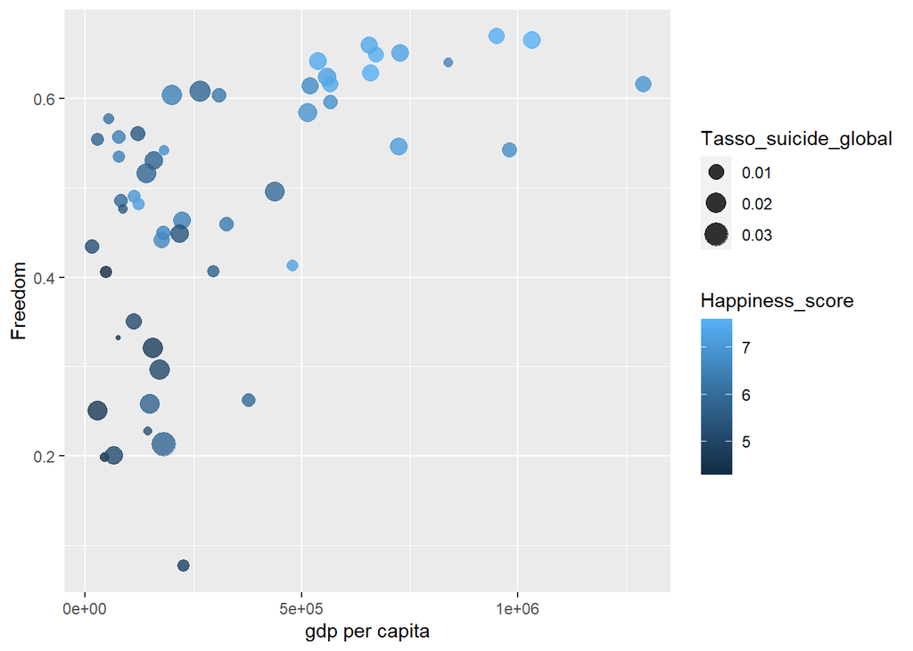

```r
  PlotFREEGDP <- happy.suicide%>%
  ggplot(aes(gdp_per_capita, Freedom ))+
  geom_point(aes(size = Tasso_suicide_global, color= Happiness_score), alpha=.8)+
  labs(x="gdp per capita")

PlotFREEGDP
```

Ovviamento il livello di suicidio è abbastanza distribuito nel nostro grafico ma se inseriamo un filtro sui top 8 per tasso di suicidi cinque di questi sono presenti in basso a sinistra

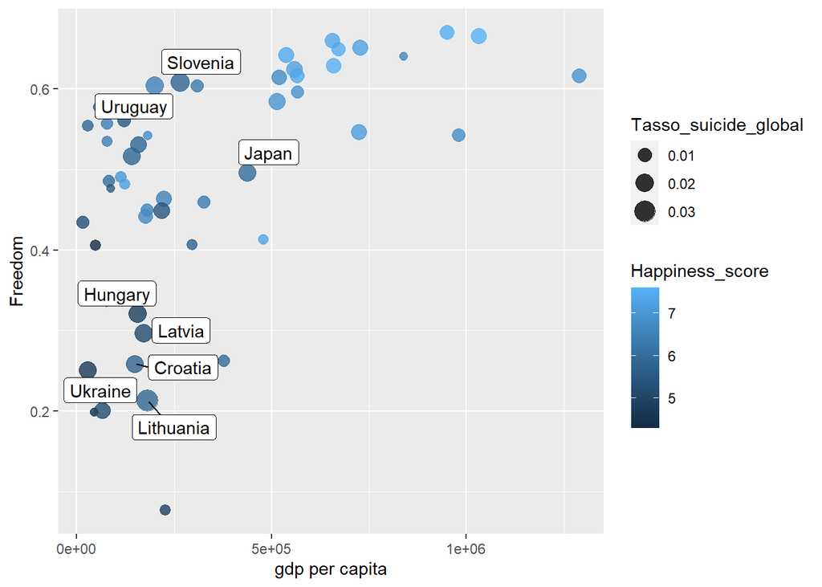

```r
  critici_top8 <- happy.suicide %>%
  top_n(8,wt=Tasso_suicide_global)

  PlotFREEGDP_8 <- happy.suicide%>%
  ggplot(aes(gdp_per_capita, Freedom ))+
  geom_point(aes(size = Tasso_suicide_global, color= Happiness_score), alpha=.8)+
  ggrepel::geom_label_repel(data = critici_top8, mapping = aes(label = country))+
  labs(x="gdp per capita")

PlotFREEGDP_8
```

##3–

Osservando i nomi degli top 8 per tasso di suicidio applichiamo un filtro colore sulle regioni e scopriamo che l’insieme dei paesi di centro e est europa sono in basso a sinistra (ovvero quelli con con Tasso di Suicidio più elevato e libertà e gdp minori), l’ovest europa in alto a destra e l’america latina in alto a sinistra(libertà elevata e gdp basso con tasso di suicidio moderato)

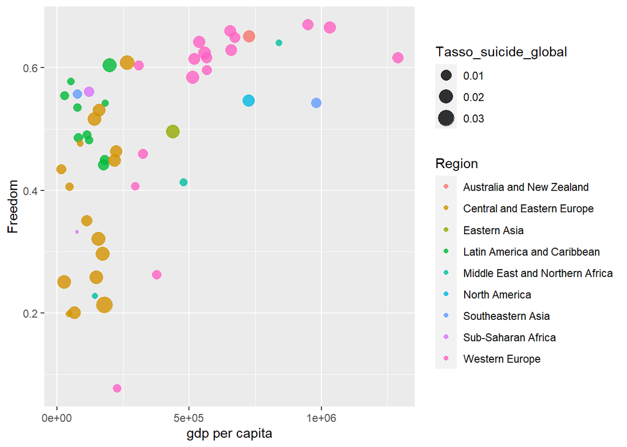

```r
  PlotFREEGDP_2 <- happy.suicide%>%
  ggplot(aes(gdp_per_capita, Freedom ))+
  geom_point(aes(size = Tasso_suicide_global, color= Region),alpha=.8)+
  labs(x="gdp per capita")

PlotFREEGDP_2
```

###——-Analisi per classi nel 2015

Per completare la nostra analisi ampliamo la nostra visione sulle generazioni. Quindi modifichiamo il dataset in modo da avere tutti i dati necessari.

```r
#Creare dataset osservazioni 2015 suicide e aggiungere dati happy ripetute per
#ogni obs di country (suicide)
suicide.2015.all <- suicide.test %>% filter(year == 2015)
```

```r
#aggiunto colonne di interesse a suicide
suicide.2015.all[,colnames(happy.test.15)[c(2,4,7,8,9,10,11)] ] <- rep(NA, nrow(suicide.2015))

country_vec <- suicide.2015.all$country[which(suicide.2015.all$country %in% happy.test.15$country)]

for (c in country_vec){
  new_row <- happy.test.15[which(happy.test.15$country == c),c(2,4,7,8,9,10,11) ]
  suicide.2015.all[which(suicide.2015.all$country == c),colnames(happy.test.15)[c(2,4,7,8,9,10,11)] ] <- new_row
}
```

```r
#Rimuovere obs suicide NA
suicide.2015.all <- suicide.2015.all[which(!is.na(suicide.2015.all$Happiness_score)),]

suicide.2015.all<- suicide.2015.all %>%
  rename('suicides_100k'= 'suicides/100k pop')

suicide.2015.all$generation <- factor(suicide.2015.all$generation, levels = c("Silent","Boomers", "Generation X","Millenials", "Generation Z"))
```

```r
#aggiungo il tasso di suicidi per ogni obs
suicide.2015.all<- suicide.2015.all %>%
                    mutate(Tasso_suicide = (suicides_no/population)*100)
```

Confronto il Tasso di suicidio e l’Happiness_score per generazioni, possiamo notare che i silent (come già visto) hanno un tasso di suicidio più elevato e che inserendo un filtro sulla gdp per capita confermiamo che i paesi con gdp alto sono sempre felici e difficilmente hanno un tasso di suicidio eleveto.

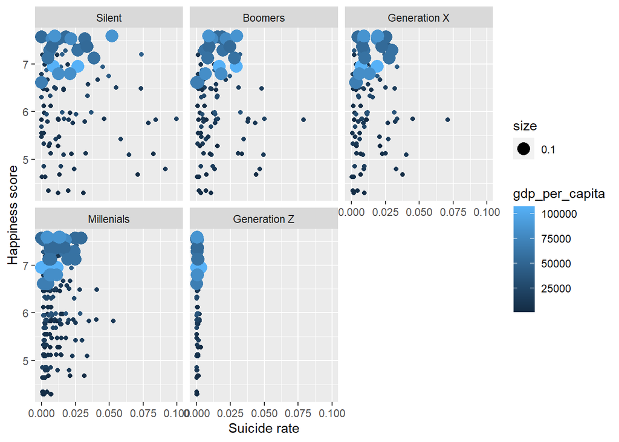

```r
up <- suicide.2015.all%>%
  filter(gdp_per_capita >= 50000)
down <- suicide.2015.all%>%
  filter(gdp_per_capita < 50000)

ConfSuicHappy <- suicide.2015.all %>%
ggplot(aes(Tasso_suicide, Happiness_score)) +
  geom_point(data= down,aes( color =gdp_per_capita)) +
  geom_point(data= up,aes( color =gdp_per_capita , size= 0.1)) +
  facet_wrap(.~generation)+ labs(x="Suicide rate", y="Happiness score")
ConfSuicHappy
```

L’ultimo grafico è una semplice conferma che i silent sono i più propensi al suicidio, e che c’è una lieve correlazione tra libertà gdp e tasso di suicidio

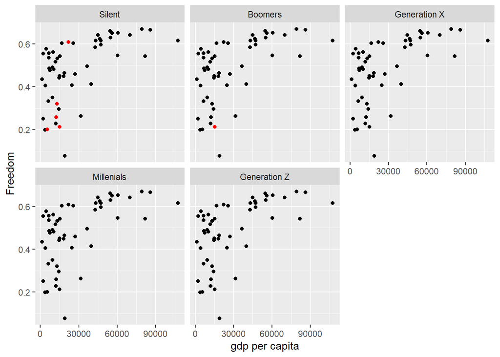

```r
critici <- suicide.2015.all %>%
  filter(Tasso_suicide > 0.075)
nonCritici <- suicide.2015.all %>%
  filter(Tasso_suicide <= 0.075)

CriticiGraf<-suicide.2015.all%>%
  ggplot(aes(gdp_per_capita ,Freedom ))+
  geom_point(data  = nonCritici, aes(`gdp_per_capita`, Freedom))+
  geom_point(data  = critici, aes(`gdp_per_capita`, Freedom), color = 'red') +
  labs(x="gdp per capita")+
  facet_wrap(.~generation)

CriticiGraf
```

###——-Conclusione

Per concludere si può affermare che la Lithuania si posiziona sempre al primo posto per tasso di suicidio, i maschi hanno un tasso ben tre volte superiore alle femmine e che gli over 75 sono la classe più critica per i suicidi. Inoltre, mettendo a confronto i dati per anno, negli anni 90’ si nota un picco del tasso di suicidio in diversi paesi. Sebbene inizialmente non è stata trovata nessuna correlazione tra livello di felicità e suicidio, abbiamo constatato che mettendo in campo le variabili di libertà e gdp per capita si può confermare anche se non in modo marcato, una relazione.